# Replication of Social Intuition: Behavioral and Neurobiological Considerations by Jellema et al. (2024, Frontiers in Psychology)

Author

Wilder Hartwell (wphartwell@ucsd.edu)

Published

December 10, 2025

# Introduction

**Link to experiment:** https://psyc-201.github.io/jellema2024/jellema2024_18.html

This study was a replication of Jellema et al. (2024), “Social Intuition: Behavioral and Neurobiological Considerations.” This was a social and developmental psychology experiment, looking at social intuition and its relationship to autistic traits. This study asked whether participants could implicitly and quickly learn the disposition of someone towards them, as well as whether this ability is decreased as autistic traits increase. To answer this question, Jellema et al. (2024) used social stimuli in an implicit learning paradigm.

In the acquisition phase, face morphs of dynamic facial expressions (happy or angry) in which their gaze shifts towards or away from the participant were shown to participants across multiple trials. All faces were either identity A or B. Identity A and B were showing either a positive or negative disposition towards the participant. In the test phase, implicit learning was tested using composites of maximally smiling or frowning identities A and B, progressively shifting towards more of one identity than the other. Participants were tasked with indicating whether the composite face was closer to identity A or B. The smiling and the frowning faces were tested separately. The assumption was that if the participant had learned the disposition of the two identities, they would indicate the smiling face looked more like identity A (positive disposition) and the frowning face more like identity B (negative disposition). In the original experiment, there was also a nonsocial task, but that was not replicated due to feasibility on a very short timeline.

# Methods

## Power Analysis

In RStudio, an ANOVA power analysis using the smallest original main effect of ηp<sup>2</sup> = 0.12 (disposition) found that I would need 30 participants to achieve a power of 80%. Thus, I planned to recruit 35 participants to account for exclusions. This is a feasible number of participants to recruit with the resources available.

## Planned Sample

I plan to collect 35 participants on Prolific in one day. No screening will occur other than participants being 18 or older.

## Materials

Google Gemini was used to generate the face morph stimuli. The experiment was coded in JsPsych.

> Participants were presented with short video clips (2s) depicting the frontal face view of an actor (agent A or agent B; Figure 1). Their facial expressions and gaze directions changed smoothly over the course of the clips, displaying a natural facial movement. (Jellema et al., 2024, p. 5)

> Actor A started with a happy expression looking straight ahead (at the observer), which then gradually morphed into an angry expression, while simultaneously the eye direction gradually moved away from the observer (so that in the final frame the actor looked angry away from the observer). The clips were also played backwards an equal number of times. Thus, it can be said that agent A had a positive disposition toward the observer. Agent B started with a happy expression looking away from the observer, which gradually morphed into an angry expression, while simultaneously the eye direction gradually moved toward the observer (clips were also played backwards an equal number of times). Actor B thus had a negative disposition toward the observer. (Jellema et al., 2024, p. 5)

The videos in this replication had all of the same characteristics, except instead of being computer-generated face morphs they were videos of an actual person that had been manipulated to slightly alter the identity of the actor to create identities A and B.

> In the subsequent test phase, an indirect measure was used to find out whether any implicit learning had taken place. This measure involved a morph of the facial expressions of the two identities A and B, flanked by the original neutral faces of these two identities. The eyes were covered by black boxes. The morphed identity was composed of 60% of the maximally smiling actor A and 40% the maximally smiling agent B (happy morph), and then progressed in steps of 5% toward 40% of the maximally smiling actor A and 60% the maximally smiling agent B. The same procedure was followed for the frowning actors A and B. Participants had to indicate for each morphed identity whether it resembled more closely agent A (who had a positive disposition toward the observer) or agent B (who had a negative disposition toward the observer) (Jellema et al., 2024, p. 5)

The composite and neutral photos in this replication had all of the same characteristics, except instead of being computer-generated face morphs they were photos of an actual person that had been manipulated to slightly alter the identity of the actor.

The original study used the Autism Quotient (AQ), whereas the replication used the Autism Quotient-10 (AQ-10), which has 10 questions instead of 50. This adjustment was made to make the experiment shorter, which is more appropriate for an online Prolific setting.

> Whether or not the participant had consciously detected the cue-identity contingencies was determined in a short debrief session, in which a series of questions were asked probing any awareness of the contingencies. (Jellema et al., 2024, p. 5)

This was followed in the replication. Specifically, there were two questions that asked “What was the disposition of Identity [A or B] towards you?”

## Procedure

First, participants signed the consent form and then answered the AQ-10. The experiment began with instructions that showed participants identities A and B making neutral faces side by side, in addition to instructing them to focus on the videos and be ready for attention checks. Next, participants were shown the video clips (described in materials) forwards and backwards the same number of times and in a randomized order. There were 56 acquisition trials split across two blocks with a break in between. There were four attention checks spaced roughly evenly across the acquisition trials that asked participants to select the correct color word (i.e. If you are paying attention, select ‘yellow.’). The test trials began with a screen displaying the instructions. Then, participants were shown each set of five test images two times, alternating between the smiling and frowning conditions. Next, participants answered two questions probing whether they had detected the contingencies in the experiment. Lastly, participants were debriefed and provided their completion information for Prolific. The experiment took approximately 10-15 minutes to complete.

## Analysis Plan

The first few steps of preparing the data for analysis is importing the data and parsing the JSONs that the questionnaire data is imported as. Additionally, strings need to be converted into numeric data for successful analysis. Next, the implicit learning measure is calculated, as well as total scores on the AQ-10. Then, participants are excluded. Participants are excluded for detecting the contingencies in the experiment, answering too fast or too slow on the test trials, missing responses on the test trials, failing attention checks, and taking too long to complete attention checks. Then, I move on to analysis.

The analysis begins with viewing the demographic data from the sample. Next, means of scores on the questionnaire and test trials are calculated. Then plots of accuracy and AQ-10 scores are created to get a visual sense of the distribution of the data. Following this, a figure comparing mean scores on each proportion across dispositions is created. Then, the key analysis, a two-way repeated measures ANOVA, is performed. Lastly, the correlation between autistic traits (AQ-10) and implicit learning is assessed and graphed. Below is the code used to prepare the data and perform the data analysis.

### **Load packages**

```r
library(tidyverse)
library(ggplot2) # plotting
library(ggthemes) # good for making plots pretty
library(effectsize)
library(knitr)
library(kableExtra)
library(purrr)
library(tidyr)
library(ggpubr)
library(DescTools)
```

### **Import .csv and Transpose**

Data needs to be transformed into long format

```r
#import csv
data <- read.csv(file = "/Users/wilderhartwell/Documents/jellema2024/data/Data_collection_1/final_data_JSON.csv", header = FALSE)


#make tibble
data <- tibble(data)

#filter out empty rows that jsPsych sometimes adds
data <- data %>%
  mutate(across(everything(), ~na_if(.x, ""))) %>%
  mutate(across(everything(), ~na_if(.x, " "))) %>%
  mutate(across(everything(), ~na_if(.x, "NA"))) %>%
  filter(!if_all(everything(), is.na))

# tranpose tibble
data_long <- as.data.frame(t(data))

# Rename columns
colnames(data_long) <- as.character(unlist(data_long[1, ]))  # make first row the column names
data_long <- data_long[-1, ]
```

### Parse JSONs

The questionnaires output as JSONs that then need to be parsed before the data can be used.

```r
# parse JSONs
data_long <- data_long |>
  mutate(
    Question_parsed = map(Question, jsonlite::fromJSON)
  ) |>
  unnest_wider(Question_parsed)

data_long <- data_long |>
  mutate(
    Check_parsed = map(Check, jsonlite::fromJSON))|>
  unnest_wider(Check_parsed)
```

### Replace Strings with Numeric

```r
# Recode words into numeric values
data_long <- data_long |>
  mutate(Q1_num = case_when(
      Question1 %in% c("Slightly Agree", "Definitely Agree") ~ 1,
      Question1 %in% c("Slightly Disagree", "Definitely Disagree") ~ 0,
    TRUE ~ NA_real_ # fallback for anything else
    )) |>
    mutate(Q2_num = case_when(
      Question2 %in% c("Slightly Agree", "Definitely Agree") ~ 1,
      Question2 %in% c("Slightly Disagree", "Definitely Disagree") ~ 0,
      TRUE ~ NA_real_
    )) |>
    mutate(Q3_num = case_when(
      Question3 %in% c("Slightly Agree", "Definitely Agree") ~ 1,
      Question3 %in% c("Slightly Disagree", "Definitely Disagree") ~ 0,
      TRUE ~ NA_real_
    )) |>
    mutate(Q4_num = case_when(
      Question4 %in% c("Slightly Agree", "Definitely Agree") ~ 1,
      Question4 %in% c("Slightly Disagree", "Definitely Disagree") ~ 0,
      TRUE ~ NA_real_
    )) |>
    mutate(Q5_num = case_when(
      Question5 %in% c("Slightly Agree", "Definitely Agree") ~ 1,
      Question5 %in% c("Slightly Disagree", "Definitely Disagree") ~ 0,
      TRUE ~ NA_real_
    )) |>
    mutate(Q6_num = case_when(
      Question6 %in% c("Slightly Agree", "Definitely Agree") ~ 1,
      Question6 %in% c("Slightly Disagree", "Definitely Disagree") ~ 0,
      TRUE ~ NA_real_
    )) |>
    mutate(Q7_num = case_when(
      Question7 %in% c("Slightly Agree", "Definitely Agree") ~ 1,
      Question7 %in% c("Slightly Disagree", "Definitely Disagree") ~ 0,
      TRUE ~ NA_real_
    )) |>
    mutate(Q8_num = case_when(
      Question8 %in% c("Slightly Agree", "Definitely Agree") ~ 1,
      Question8 %in% c("Slightly Disagree", "Definitely Disagree") ~ 0,
      TRUE ~ NA_real_
    )) |>
    mutate(Q9_num = case_when(
      Question9 %in% c("Slightly Agree", "Definitely Agree") ~ 1,
      Question9 %in% c("Slightly Disagree", "Definitely Disagree") ~ 0,
      TRUE ~ NA_real_
    )) |>
    mutate(Q10_num = case_when(
      Question10 %in% c("Slightly Agree", "Definitely Agree") ~ 1,
      Question10 %in% c("Slightly Disagree", "Definitely Disagree") ~ 0,
      TRUE ~ NA_real_
    )) |>
    mutate(CheckQ1_num = case_when(
      CheckQ1 %in% c("I do not know") ~ 0,
      CheckQ1 %in% c("Negative") ~ 1,
      CheckQ1 %in% c("Neutral") ~ 2,
      CheckQ1 %in% c("Positive") ~ 3,
      TRUE ~ NA_real_
    )) |>
    mutate(CheckQ2_num = case_when(
      CheckQ2 %in% c("I do not know") ~ 0,
      CheckQ2 %in% c("Negative") ~ 1,
      CheckQ2 %in% c("Neutral") ~ 2,
      CheckQ2 %in% c("Positive") ~ 3,
      TRUE ~ NA_real_
    )) |>
    mutate(frown50_1_num = case_when(
      frown50_1 %in% c("f") ~ 0,
      frown50_1 %in% c("j") ~ 1,
      TRUE ~ NA_real_
    )) |>
    mutate(frown50_2_num = case_when(
      frown50_2 %in% c("f") ~ 0,
      frown50_2 %in% c("j") ~ 1,
      TRUE ~ NA_real_
    )) |>
    mutate(smile50_1_num = case_when(
      smile50_1 %in% c("f") ~ 0,
      smile50_1 %in% c("j") ~ 1,
      TRUE ~ NA_real_
    )) |>
    mutate(smile50_2_num = case_when(
      smile50_2 %in% c("f") ~ 0,
      smile50_2 %in% c("j") ~ 1,
      TRUE ~ NA_real_
    )) |>
    mutate(frown50_1_cor_num = case_when(
      frown50_1_cor %in% c("FALSE") ~ 0,
      frown50_1_cor %in% c("TRUE") ~ 1,
      TRUE ~ NA_real_
    )) |>
    mutate(frown50_2_cor_num = case_when(
      frown50_2_cor %in% c("FALSE") ~ 0,
      frown50_2_cor %in% c("TRUE") ~ 1,
      TRUE ~ NA_real_
    )) |>
    mutate(smile50_1_cor_num = case_when(
      smile50_1_cor %in% c("FALSE") ~ 0,
      smile50_1_cor %in% c("TRUE") ~ 1,
      TRUE ~ NA_real_
    )) |>
    mutate(smile50_2_cor_num = case_when(
      smile50_2_cor %in% c("FALSE") ~ 0,
      smile50_2_cor %in% c("TRUE") ~ 1,
      TRUE ~ NA_real_
    )) |>
    mutate(gender_num = case_when(
      Q_gender %in% c("Woman") ~ 0,
      Q_gender %in% c("Man") ~ 1,
      Q_gender %in% c("Nonbinary/other") ~ 2,
      TRUE ~ NA_real_
    )) |>
    mutate(age_num = case_when(
      Q_age %in% c("18-24") ~ 0,
      Q_age %in% c("25-34") ~ 1,
      Q_age %in% c("35-44") ~ 2,
      Q_age %in% c("45-54") ~ 3,
      Q_age %in% c("55-64") ~ 4,
      Q_age %in% c("65+") ~ 5,
      TRUE ~ NA_real_
    ))
```

### **Prepare main data frame**

#### **Calculate Scores**

```r
#the difference between the frown and smile at 50/50 (used in correlation)
FrownScore <- data_long$frown50_1_cor_num + data_long$frown50_2_cor_num #sum the frown score
FrownScore #print the frown score
```

```
 [1] 2 0 1 0 1 0 0 2 2 0 1 0 1 1 0 2 2 1 1 0 0 0 1 2 1 0 1 0 1 1 1 0 0 0 2 0 2
```

```r
SmileScore <- data_long$smile50_1_cor_num + data_long$smile50_2_cor_num #sum the smile score
SmileScore #print the smile score
```

```
 [1] 2 1 1 1 1 1 2 2 1 2 2 0 2 1 2 0 2 0 2 2 0 2 1 2 1 0 1 2 0 2 2 0 0 2 2 0 1
```

```r
TestScore <- FrownScore - SmileScore #calculate TestScore
TestScore <- abs(TestScore) # turn negative numbers into positive numbers (absolute value)

data_long <- bind_cols(data_long, TestScore)
#Score the AQ-10
AQScore <- rowSums(data_long[, c("Q1_num","Q2_num", "Q3_num", "Q4_num", "Q5_num", "Q6_num", "Q7_num", "Q8_num", "Q9_num", "Q10_num")])
as.data.frame(AQScore)
```

```
   AQScore
1        6
2        5
3        5
4        6
5        7
6        8
7        4
8        7
9        4
10       4
11       8
12       7
13       5
14       4
```

[output cut: 23 more lines]

```r
data_long <- bind_cols(data_long, AQScore)
data_long <- data_long %>%
  rename(AQScore = `...61`)

#make tibble again
data_long <- tibble(data_long)
```

#### **Exclude participants**

```r
# Calculate total participants and store it in n_total
n_total <- n_distinct(data_long$ID)

# Exclude for detecting contingencies
excluded_detection <- data_long %>%
  filter(CheckQ1 == "Positive" & CheckQ2 == "Negative") %>%
  pull(ID)

# Exclude participants that missed all 50/50 response trials
excluded_missing <- data_long %>%
  filter(is.na(frown50_1_num) &
         is.na(smile50_1_num) &
         is.na(frown50_2_num) &
         is.na(smile50_2_num)) %>%
  pull(ID)


# Collect initial exclusion IDs
excluded_initial <- unique(c(excluded_detection, excluded_missing))

# Remove these from main dataset before further checks
data_complete <- data_long %>%
  filter(!(ID %in% excluded_initial))


# Exclude for out of range reaction time and failing attention checks
rt_attention_cols  <- c("rt_attention_1", "rt_attention_2", "rt_attention_3", "rt_attention_4")
acc_attention_cols <- c("attention_1",   "attention_2",   "attention_3",   "attention_4")
rt_test_cols       <- c("rt_frown_1", "rt_smile_1", "rt_frown_2", "rt_smile_2")

# Convert columns
data_complete <- data_complete %>%
  mutate(across(all_of(c(rt_attention_cols, rt_test_cols)), ~ as.numeric(as.character(.))),
         across(all_of(acc_attention_cols), ~ as.integer(as.character(.))))

data_complete <- data_complete %>%
  mutate(
    fail_attention_rt  = if_any(all_of(rt_attention_cols),  ~ .x > 11000),
    fail_attention_acc = if_any(all_of(acc_attention_cols), ~ .x == 0),
    fail_test_rt       = if_any(all_of(rt_test_cols),       ~ (.x <= 400 | .x > 30000))
  )

# Build a table of participants and reasons for exclusion

# Helper: convert logical flags into reason labels
reason_map <- c(
  fail_detection      = "Detected Contingencies",
  fail_missing        = "Missing All 50/50 Trials",
  fail_attention_rt   = "Attention RT > 11000",
  fail_attention_acc  = "Incorrect Attention Check",
  fail_test_rt        = "Test Trial RT Out of Range"
)

# Initial exclusion table
initial_df <- tibble(
    ID = excluded_initial,
    fail_detection = excluded_initial %in% excluded_detection,
    fail_missing   = excluded_initial %in% excluded_missing
) %>%
    pivot_longer(
        cols = starts_with("fail_"),
        names_to = "flag",
        values_to = "value"
    ) %>%
    filter(value) %>%
    mutate(Reason = reason_map[flag] %||% NA_character_) %>%
    select(ID, Reason)

# DIAGNOSTIC — must be separate
data_complete %>%
  select(ID, starts_with("fail_")) %>%
  pivot_longer(cols = starts_with("fail_"),
               names_to = "flag", values_to = "value") %>%
  count(flag, value)
```

```
# A tibble: 5 × 3
  flag               value     n
  <chr>              <lgl> <int>
1 fail_attention_acc FALSE    33
2 fail_attention_rt  FALSE    30
3 fail_attention_rt  TRUE      3
4 fail_test_rt       FALSE    30
5 fail_test_rt       TRUE      3
```

```r
# Build long-format table of later RT/ACC exclusions
late_df <- data_complete %>%
  select(ID, starts_with("fail_")) %>%
  distinct() %>%
  pivot_longer(
    cols      = starts_with("fail_"),
    names_to  = "flag",
    values_to = "value"
  ) %>%
  filter(value == TRUE) %>%
  mutate(
    Reason = dplyr::recode(flag, !!!reason_map, .default = NA_character_)
  ) %>%
  select(ID, Reason)

# Combine ALL reasons
excluded_df_long <- bind_rows(initial_df, late_df) %>%
  distinct()

# Save excluded list
write.csv(excluded_df_long, "excluded_participants_long.csv", row.names = FALSE)

# 6. Final cleaned dataset
all_excluded_ids <- unique(excluded_df_long$ID)

data_complete <- data_long %>%
  filter(!(ID %in% all_excluded_ids))

# Print summary
cat("======== EXCLUSION SUMMARY ========\n")
```

```
======== EXCLUSION SUMMARY ========
```

```r
cat("Total participants:", n_total, "\n")
```

```
Total participants: 37
```

```r
cat("Excluded:", length(all_excluded_ids), "\n")
```

```
Excluded: 9
```

```r
cat("Remaining:", n_distinct(data_complete$ID), "\n\n")
```

```
Remaining: 28
```

```r
cat("Sample of multi-reason exclusions:\n")
```

```
Sample of multi-reason exclusions:
```

```r
print(head(excluded_df_long))
```

```
# A tibble: 6 × 2
  ID         Reason
  <chr>      <chr>
1 uycua16rbs Detected Contingencies
2 rv437srgtr Detected Contingencies
3 nz1u6exavc Detected Contingencies
4 3zmwaqv271 Detected Contingencies
5 b5183qbwfj Test Trial RT Out of Range
6 dm31sblpep Attention RT > 11000
```

### **Demographics**

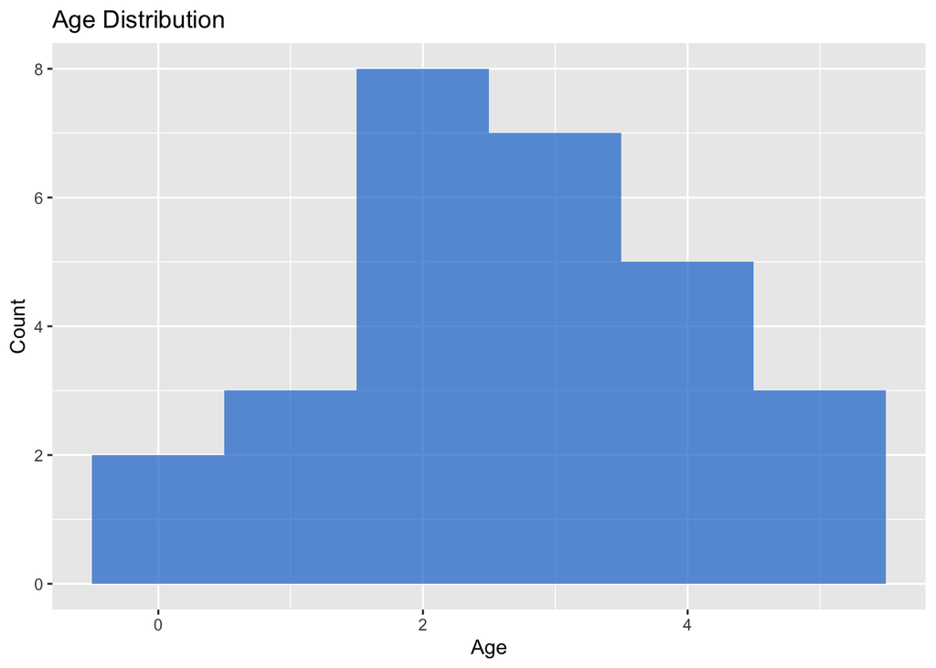

```r
# Age distribution
ggplot(data_complete, aes(x = age_num)) +
  geom_histogram(binwidth = 1, fill = "#1976D2", alpha = 0.7) +
  labs(title = "Age Distribution",
       x = "Age",
       y = "Count")
```

```r
summary(data_complete$age_num)
```

```
   Min. 1st Qu.  Median    Mean 3rd Qu.    Max.
  0.000   2.000   3.000   2.679   4.000   5.000
```

```r
# Age summary
data_complete %>%
  summarise(
    mean_age = mean(age_num, na.rm = TRUE),
    sd_age = sd(age_num, na.rm = TRUE),
    min_age = min(age_num, na.rm = TRUE),
    max_age = max(age_num, na.rm = TRUE),
    mode_age = Mode(age_num)
  ) %>%
  kable(digits = 2) %>%
  kable_styling(bootstrap_options = c("striped", "hover"), full_width = FALSE)
```

| mean_age | sd_age | min_age | max_age | mode_age |
| --- | --- | --- | --- | --- |
| 2.68 | 1.39 | 0 | 5 | 2 |

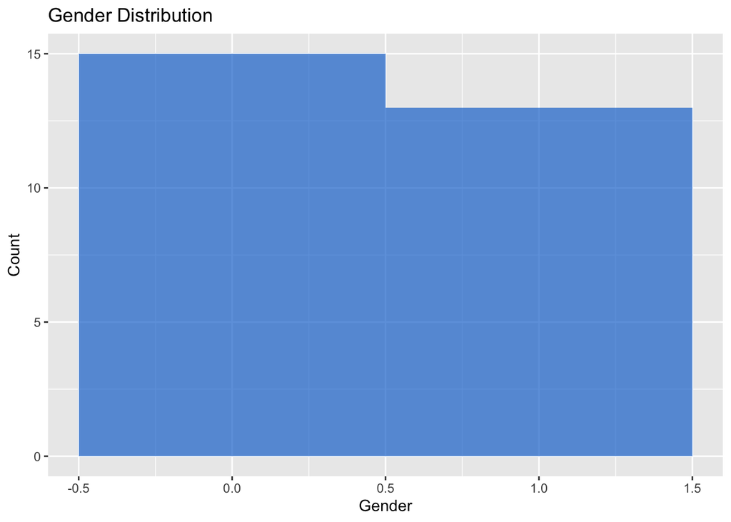

```r
# Gender distribution
ggplot(data_complete, aes(x = gender_num)) +
  geom_histogram(binwidth = 1, fill = "#1976D2", alpha = 0.7) +
  labs(title = "Gender Distribution",
       x = "Gender",
       y = "Count")
```

### **Mean score**

```r
# sum of scores on 50/50 trials
acc_sum <- data_complete$frown50_1_cor_num + data_complete$frown50_2_cor_num + data_complete$smile50_1_cor_num + data_complete$smile50_2_cor_num
as.data.frame(acc_sum)
```

```
   acc_sum
1        4
2        1
3        2
4        1
5        2
6        4
7        2
8        0
9        3
10       2
11       2
12       2
13       1
14       2
15       0
16       2
17       2
18       0
19       2
20       2
21       1
22       3
23       3
24       0
25       0
26       2
27       4
28       0
```

```r
data_complete <- bind_cols(data_complete, acc_sum)
data_complete <- data_complete %>%
  rename(acc_sum = `...62`)
# mean TestScore
acc_mean <- mean(TestScore)
acc_mean
```

```
[1] 0.7567568
```

```r
# mean of sum of scores on 50/50 trials
acc_mean_sum <- mean(data_complete$frown50_1_cor_num + data_complete$frown50_2_cor_num + data_complete$smile50_1_cor_num + data_complete$smile50_2_cor_num)
acc_mean_sum
```

```
[1] 1.75
```

```r
# Austim Quotient-10 mean score
AQ_mean <- mean(data_complete$...61)
AQ_mean
```

```
[1] NA
```

### Plot Accuracy and AQ-10 Scores

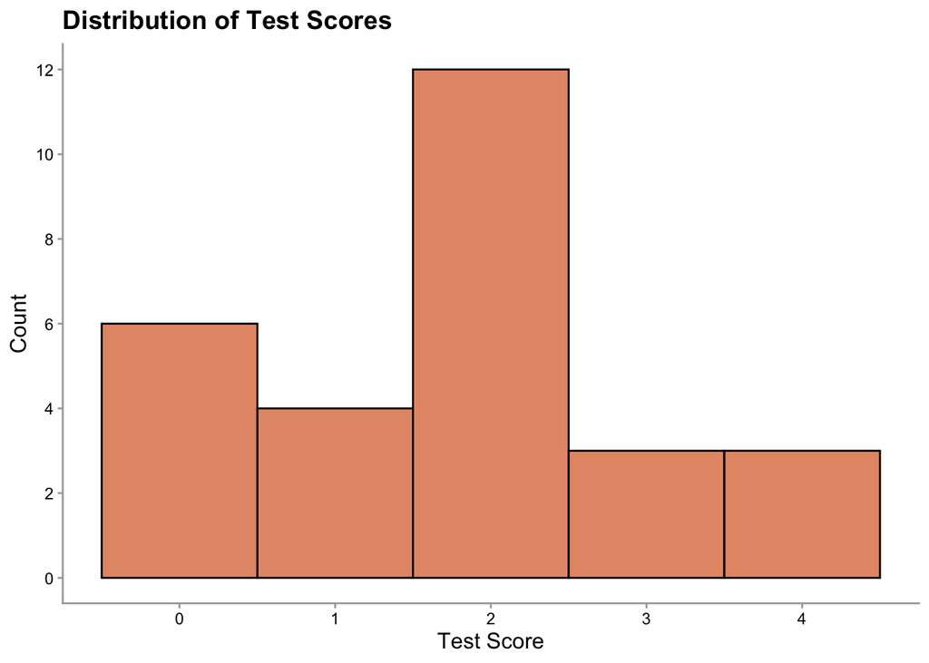

```r
# histogram of accuracy on test trials
histogram <- ggplot(data_complete, aes(x = acc_sum)) +
  geom_histogram(
    binwidth = 1,        # adjust as needed
    fill = "#d96627",
    color = "black",
    alpha = 0.7
  ) +
  scale_y_continuous(breaks = c(0, 2, 4, 6, 8, 10, 12)) +
  theme_classic() +
  theme(
    legend.position = "none",

    # Axis line color
    axis.line = element_line(color = "darkgray"),

    # Tick mark color
    axis.ticks = element_line(color = "darkgray"),

    # Axis text color
    axis.text = element_text(color = "black"),

    # Title color
    plot.title = element_text(color = "black", size = 14, face = "bold"),

    # Axis label color
    axis.title = element_text(color = "black", size = 12)
  ) +
  labs(
    title = "Distribution of Test Scores",
    x = "Test Score",
    y = "Count"
  )
histogram # show histogram
```

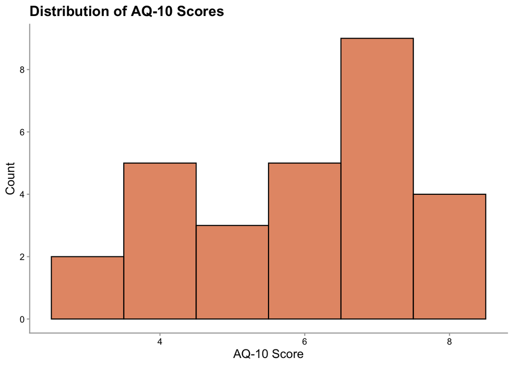

```r
# save histogram
ggsave(
  "accdistribution.png",
  plot = histogram,
  width = 5,    # inches
  height = 4,   # inches
  dpi = 300
)

# histogram of AQ-10 scores
histogramAQ <- ggplot(data_complete, aes(x = AQScore)) +
  geom_histogram(
    binwidth = 1,        # adjust as needed
    fill = "#d96627",
    color = "black",
    alpha = 0.7
  ) +
  scale_y_continuous(breaks = c(0, 2, 4, 6, 8, 10)) +
  theme_classic() +
  theme(
    legend.position = "none",

    # Axis line color
    axis.line = element_line(color = "darkgray"),

    # Tick mark color
    axis.ticks = element_line(color = "darkgray"),

    # Axis text color
    axis.text = element_text(color = "black"),

    # Title color
    plot.title = element_text(color = "black", size = 14, face = "bold"),

    # Axis label color
    axis.title = element_text(color = "black", size = 12)
  ) +
  labs(
    title = "Distribution of AQ-10 Scores",
    x = "AQ-10 Score",
    y = "Count"
  )
histogramAQ # show histogram
```

```r
# save histogram
ggsave(
  "AQ-10distribution.png",
  plot = histogramAQ,
  width = 6,    # inches
  height = 4,   # inches
  dpi = 300
)
```

### **ANOVA**

This spreadsheet is constructed outside of R without the excluded participants

```r
# import csv
A_data <- read.csv(file = "/Users/wilderhartwell/Documents/jellema2024/data/Data_collection_1/final_data_ANOVA.csv")

# turn letter responses into numbers
A_data <- A_data |>
  mutate(Response_num = case_when(
      Response %in% c("f") ~ 0,
      Response %in% c("j") ~ 1,
    TRUE ~ NA_real_ # fallback for anything else
    ))
```

#### Score correct responses and create figure

[figure not shown]

```r
# score correct responses and create figure

# Load data
correct_response <- read.csv("/Users/wilderhartwell/Documents/jellema2024/data/Data_collection_1/correct_response.csv")

# Merge A_data with correct-response key
A_scored <- A_data %>%
  left_join(correct_response, by = "Proportion")
# Create accuracy column (1 = correct, -1 = incorrect)
A_scored <- A_scored %>%
  mutate(
    accuracy = if_else(Response == CorrectResponse, 1, -1)
  )
# Get mean score for each proportion across dispositions
accuracy_summary <- A_scored %>%
  group_by(Disposition.y, Proportion) %>%
  summarise(
    mean_accuracy = mean(accuracy, na.rm = TRUE),
    n = n(),
    se = sd(accuracy, na.rm = TRUE) / sqrt(n)
  )
#export CSV to rename Proportion values
write.csv(accuracy_summary, file = "accuracy_summary.csv")

#import CSV back in to use in the graph
accuracy_summary <- read.csv(file = "/Users/wilderhartwell/Documents/jellema2024/writeup/accuracy_summary.csv")

# set correct factor structure to ensure x axis is correctly displayed
accuracy_summary$Proportion <- factor(
  accuracy_summary$Proportion,
  levels = c("60% A 40% B",
             "55% A 45% B",
             "50% A 50% B",
             "45% A 55% B",
             "40% A 60% B"))
#create graph
jellemaplot <- ggplot(accuracy_summary, aes(x = Proportion, y = mean_accuracy, color = Disposition.y, group = Disposition.y)) +

  geom_line(size = 1.4) +

  scale_color_manual(
    values = c(
      "frown" = "#B22222",  # deep red
      "smile"  = "#1E90FF"   # blue
    ),
    name = NULL,
    labels = c("frowning morph", "smiling morph")
  ) +

  scale_y_continuous(limits = c(-1, 1), breaks = seq(-1, 1, 0.2)) +

  labs(
    title = "Social",
    y = "mean score",
    x = "morph proportion"
  ) +

  theme_classic() +
  theme(
    plot.title = element_text(size = 22, hjust = 0.5, face = "bold"),
    legend.position = "top",
    legend.text = element_text(size = 14),
    axis.title = element_text(size = 14),
    axis.text  = element_text(size = 12),
    axis.line  = element_line(color = "black"),
    panel.grid.major = element_line(color = "gray85"),
    panel.grid.minor = element_blank()
  )
jellemaplot # Show graph
```

```r
# Save graph
ggsave(
  "jellemaplot.png",
  plot = jellemaplot,
  width = 6.5,    # inches
  height = 4,   # inches
  dpi = 300
)
```

#### **Run ANOVA**

```r
#run two-way repeated measures ANOVA using aov
model.aov <- aov(
  Response_num ~ Disposition * Proportion +
    Error(ID / (Disposition * Proportion)),
  data = A_data
)
summary(model.aov)
```

```
Error: ID
          Df Sum Sq Mean Sq F value Pr(>F)
Residuals 27  27.59   1.022

Error: ID:Disposition
            Df Sum Sq Mean Sq F value Pr(>F)
Disposition  1   1.61   1.607   1.223  0.279
Residuals   27  35.49   1.315

Error: ID:Proportion
           Df Sum Sq Mean Sq F value Pr(>F)
Proportion  1  0.004 0.00357   0.016    0.9
Residuals  27  5.996 0.22209

Error: ID:Disposition:Proportion
                       Df Sum Sq Mean Sq F value Pr(>F)
Disposition:Proportion  1  0.175  0.1750   0.759  0.391
Residuals              27  6.225  0.2306

Error: Within
           Df Sum Sq Mean Sq F value Pr(>F)
Residuals 448   55.6  0.1241
```

```r
lapply(A_data[, c("Disposition","Proportion","ID")], function(x) {
  list(
    class = class(x),
    has_na = any(is.na(x)),
    has_blank = any(x == "" )
  )
})
```

```
$Disposition
$Disposition$class
[1] "character"

$Disposition$has_na
[1] FALSE

$Disposition$has_blank
[1] FALSE


$Proportion
$Proportion$class
[1] "integer"

$Proportion$has_na
[1] FALSE

$Proportion$has_blank
[1] FALSE


$ID
$ID$class
[1] "character"

$ID$has_na
[1] FALSE

$ID$has_blank
[1] FALSE
```

```r
effectsize(model.aov)
```

```
# Effect Size for ANOVA (Type I)

Group                     |              Parameter | Eta2 (partial) |       95% CI
----------------------------------------------------------------------------------
ID:Disposition            |            Disposition |           0.04 | [0.00, 1.00]
ID:Proportion             |             Proportion |       5.95e-04 | [0.00, 1.00]
ID:Disposition:Proportion | Disposition:Proportion |           0.03 | [0.00, 1.00]

- One-sided CIs: upper bound fixed at [1.00].
```

### **Correlation**

Correlation test of AQ-10 score and TestScore

```r
# correlation test
cor.test(AQScore, TestScore)
```

```
    Pearson's product-moment correlation

data:  AQScore and TestScore
t = 0.37444, df = 35, p-value = 0.7103
alternative hypothesis: true correlation is not equal to 0
95 percent confidence interval:
 -0.2663046  0.3794183
sample estimates:
       cor
0.06316469
```

#### Plot Correlation

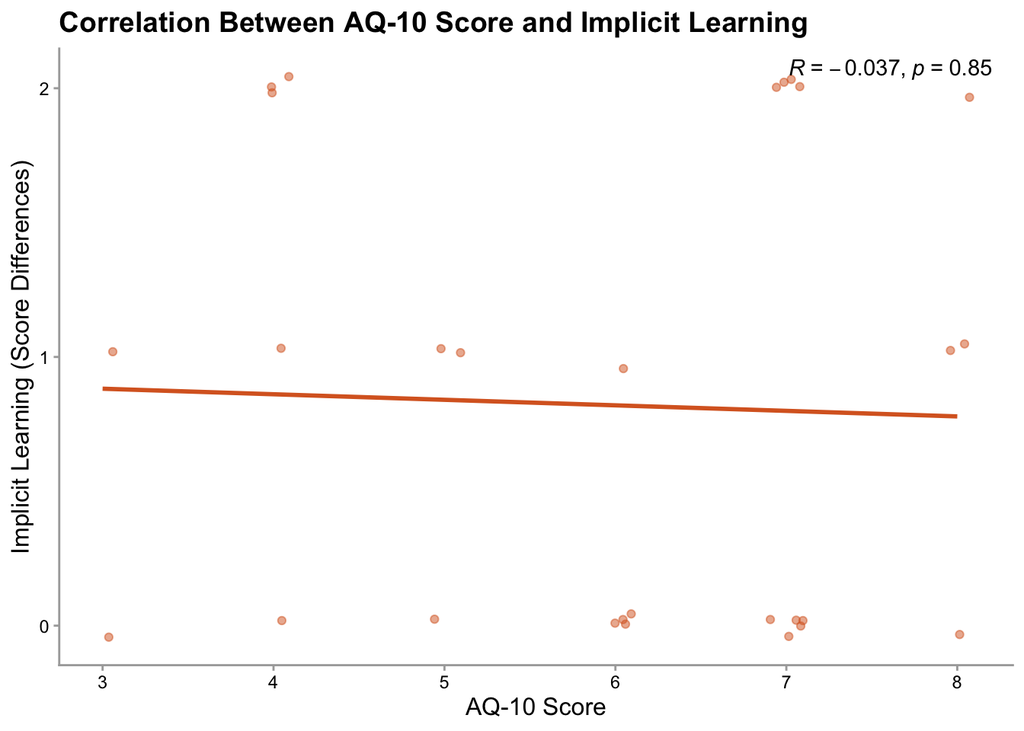

```r
corplot <- ggplot(data_complete, aes(x = AQScore, y = ...60)) +
  geom_jitter(width = 0.1, height = 0.05, color = "#d96627", alpha = 0.5) +
  geom_smooth(method = "lm", se = FALSE, color = "#d96627") +
  stat_cor(
    method = "pearson",
    label.x = Inf, label.y = Inf,
    hjust = 1.1, vjust = 1.5,
    color = "black"     # ensure text stays black
  ) +
  scale_y_continuous(breaks = c(0, 1, 2)) +
  theme_classic() +
  theme(
    legend.position = "none",

    # Axis line color
    axis.line = element_line(color = "darkgray"),

    # Tick mark color
    axis.ticks = element_line(color = "darkgray"),

    # Axis text color
    axis.text = element_text(color = "black"),

    # Title color
    plot.title = element_text(color = "black", size = 14, face = "bold"),

    # Axis label color
    axis.title = element_text(color = "black", size = 12)
  ) +
  labs(
    x = "AQ-10 Score",
    y = "Implicit Learning (Score Differences)",
    title = "Correlation Between AQ-10 Score and Implicit Learning"
  )
corplot
```

```r
ggsave(
  "corplot.png",
  plot = corplot,
  width = 6,    # inches
  height = 4,   # inches
  dpi = 300
)
```

## Differences from Original Study

The first difference between Jellema et al. (2024) and this replication was that Jellema et al. (2024) used the AQ, and this replication used the AQ-10. The AQ-10, which has 10 questions, has been validated as working as well as the 50 question original, so this is not expected to create differences in results. The most significant difference is that the replication stimuli used videos of a real person manipulated to slightly alter the actor’s identity, creating identities A and B, while the original study used computer-generated face morphs. This may make a difference in the results as stimuli are centrally important to experimental results. Additionally, there were 56 trials in the replicated acquisition phase, but the number of trials in the original is unknown. While I have done my best to estimate how many trials there would be based on context in the original paper, if this is a significantly different number of trials, that could create differences in learning outcomes. Lastly, there was a nonsocial task in Jellema et al. (2024) that I did not attempt to replicate in this study due to tight time and feasability constraints.

## Methods Addendum (Post Data Collection)

### Actual Sample

37 participants were collected and nine were excluded, resulting in a final sample of 28 participants. This is close to the goal of 30 participants. Participants were excluded for detecting the contingencies in the experiment, reaction time on test trials below 400ms or above 30s, and attention check reaction times above 11s. Participants also would have been excluded for missing responses on the test trials, but no one had missing trials. The most common age for participants was between 35-44 years old. Additionally, 46% of participants were men.

### Differences from pre-data collection methods plan

Stimuli were not generated using Google Gemini, but instead videos were taken of a person and then manipulated to slightly alter the identity of the actor to create identities A and B. Additionally, the study took slightly less time than expected, averaging between 7-12 minutes.

# Results

## Data preparation

To prepare the data, I used RStudio. Full data preparation code is shown below.

### **Import .csv and Transpose**

Data needs to be transformed into long format

```r
#import csv
data <- read.csv(file = "/Users/wilderhartwell/Documents/jellema2024/data/Data_collection_1/final_data_JSON.csv", header = FALSE)


#make tibble
data <- tibble(data)

#filter out empty rows that jsPsych sometimes adds
data <- data %>%
  mutate(across(everything(), ~na_if(.x, ""))) %>%
  mutate(across(everything(), ~na_if(.x, " "))) %>%
  mutate(across(everything(), ~na_if(.x, "NA"))) %>%
  filter(!if_all(everything(), is.na))

# tranpose tibble
data_long <- as.data.frame(t(data))

# Rename columns
colnames(data_long) <- as.character(unlist(data_long[1, ]))  # make first row the column names
data_long <- data_long[-1, ]
```

### Parse JSONs

The questionnaires output as JSONs that then need to be parsed before the data can be used.

```r
# parse JSONs
data_long <- data_long |>
  mutate(
    Question_parsed = map(Question, jsonlite::fromJSON)
  ) |>
  unnest_wider(Question_parsed)

data_long <- data_long |>
  mutate(
    Check_parsed = map(Check, jsonlite::fromJSON))|>
  unnest_wider(Check_parsed)
```

### Replace Strings with Numeric

```r
# Recode words into numeric values
data_long <- data_long |>
  mutate(Q1_num = case_when(
      Question1 %in% c("Slightly Agree", "Definitely Agree") ~ 1,
      Question1 %in% c("Slightly Disagree", "Definitely Disagree") ~ 0,
    TRUE ~ NA_real_ # fallback for anything else
    )) |>
    mutate(Q2_num = case_when(
      Question2 %in% c("Slightly Agree", "Definitely Agree") ~ 1,
      Question2 %in% c("Slightly Disagree", "Definitely Disagree") ~ 0,
      TRUE ~ NA_real_
    )) |>
    mutate(Q3_num = case_when(
      Question3 %in% c("Slightly Agree", "Definitely Agree") ~ 1,
      Question3 %in% c("Slightly Disagree", "Definitely Disagree") ~ 0,
      TRUE ~ NA_real_
    )) |>
    mutate(Q4_num = case_when(
      Question4 %in% c("Slightly Agree", "Definitely Agree") ~ 1,
      Question4 %in% c("Slightly Disagree", "Definitely Disagree") ~ 0,
      TRUE ~ NA_real_
    )) |>
    mutate(Q5_num = case_when(
      Question5 %in% c("Slightly Agree", "Definitely Agree") ~ 1,
      Question5 %in% c("Slightly Disagree", "Definitely Disagree") ~ 0,
      TRUE ~ NA_real_
    )) |>
    mutate(Q6_num = case_when(
      Question6 %in% c("Slightly Agree", "Definitely Agree") ~ 1,
      Question6 %in% c("Slightly Disagree", "Definitely Disagree") ~ 0,
      TRUE ~ NA_real_
    )) |>
    mutate(Q7_num = case_when(
      Question7 %in% c("Slightly Agree", "Definitely Agree") ~ 1,
      Question7 %in% c("Slightly Disagree", "Definitely Disagree") ~ 0,
      TRUE ~ NA_real_
    )) |>
    mutate(Q8_num = case_when(
      Question8 %in% c("Slightly Agree", "Definitely Agree") ~ 1,
      Question8 %in% c("Slightly Disagree", "Definitely Disagree") ~ 0,
      TRUE ~ NA_real_
    )) |>
    mutate(Q9_num = case_when(
      Question9 %in% c("Slightly Agree", "Definitely Agree") ~ 1,
      Question9 %in% c("Slightly Disagree", "Definitely Disagree") ~ 0,
      TRUE ~ NA_real_
    )) |>
    mutate(Q10_num = case_when(
      Question10 %in% c("Slightly Agree", "Definitely Agree") ~ 1,
      Question10 %in% c("Slightly Disagree", "Definitely Disagree") ~ 0,
      TRUE ~ NA_real_
    )) |>
    mutate(CheckQ1_num = case_when(
      CheckQ1 %in% c("I do not know") ~ 0,
      CheckQ1 %in% c("Negative") ~ 1,
      CheckQ1 %in% c("Neutral") ~ 2,
      CheckQ1 %in% c("Positive") ~ 3,
      TRUE ~ NA_real_
    )) |>
    mutate(CheckQ2_num = case_when(
      CheckQ2 %in% c("I do not know") ~ 0,
      CheckQ2 %in% c("Negative") ~ 1,
      CheckQ2 %in% c("Neutral") ~ 2,
      CheckQ2 %in% c("Positive") ~ 3,
      TRUE ~ NA_real_
    )) |>
    mutate(frown50_1_num = case_when(
      frown50_1 %in% c("f") ~ 0,
      frown50_1 %in% c("j") ~ 1,
      TRUE ~ NA_real_
    )) |>
    mutate(frown50_2_num = case_when(
      frown50_2 %in% c("f") ~ 0,
      frown50_2 %in% c("j") ~ 1,
      TRUE ~ NA_real_
    )) |>
    mutate(smile50_1_num = case_when(
      smile50_1 %in% c("f") ~ 0,
      smile50_1 %in% c("j") ~ 1,
      TRUE ~ NA_real_
    )) |>
    mutate(smile50_2_num = case_when(
      smile50_2 %in% c("f") ~ 0,
      smile50_2 %in% c("j") ~ 1,
      TRUE ~ NA_real_
    )) |>
    mutate(frown50_1_cor_num = case_when(
      frown50_1_cor %in% c("FALSE") ~ 0,
      frown50_1_cor %in% c("TRUE") ~ 1,
      TRUE ~ NA_real_
    )) |>
    mutate(frown50_2_cor_num = case_when(
      frown50_2_cor %in% c("FALSE") ~ 0,
      frown50_2_cor %in% c("TRUE") ~ 1,
      TRUE ~ NA_real_
    )) |>
    mutate(smile50_1_cor_num = case_when(
      smile50_1_cor %in% c("FALSE") ~ 0,
      smile50_1_cor %in% c("TRUE") ~ 1,
      TRUE ~ NA_real_
    )) |>
    mutate(smile50_2_cor_num = case_when(
      smile50_2_cor %in% c("FALSE") ~ 0,
      smile50_2_cor %in% c("TRUE") ~ 1,
      TRUE ~ NA_real_
    )) |>
    mutate(gender_num = case_when(
      Q_gender %in% c("Woman") ~ 0,
      Q_gender %in% c("Man") ~ 1,
      Q_gender %in% c("Nonbinary/other") ~ 2,
      TRUE ~ NA_real_
    )) |>
    mutate(age_num = case_when(
      Q_age %in% c("18-24") ~ 0,
      Q_age %in% c("25-34") ~ 1,
      Q_age %in% c("35-44") ~ 2,
      Q_age %in% c("45-54") ~ 3,
      Q_age %in% c("55-64") ~ 4,
      Q_age %in% c("65+") ~ 5,
      TRUE ~ NA_real_
    ))
```

### **Prepare main data frame**

#### **Calculate Scores**

```r
#the difference between the frown and smile at 50/50 (used in correlation)
FrownScore <- data_long$frown50_1_cor_num + data_long$frown50_2_cor_num #sum the frown score
FrownScore #print the frown score
```

```
 [1] 2 0 1 0 1 0 0 2 2 0 1 0 1 1 0 2 2 1 1 0 0 0 1 2 1 0 1 0 1 1 1 0 0 0 2 0 2
```

```r
SmileScore <- data_long$smile50_1_cor_num + data_long$smile50_2_cor_num #sum the smile score
SmileScore #print the smile score
```

```
 [1] 2 1 1 1 1 1 2 2 1 2 2 0 2 1 2 0 2 0 2 2 0 2 1 2 1 0 1 2 0 2 2 0 0 2 2 0 1
```

```r
TestScore <- FrownScore - SmileScore #calculate TestScore
TestScore <- abs(TestScore) # turn negative numbers into positive numbers (absolute value)

data_long <- bind_cols(data_long, TestScore)
#Score the AQ-10
AQScore <- rowSums(data_long[, c("Q1_num","Q2_num", "Q3_num", "Q4_num", "Q5_num", "Q6_num", "Q7_num", "Q8_num", "Q9_num", "Q10_num")])
as.data.frame(AQScore)
```

```
   AQScore
1        6
2        5
3        5
4        6
5        7
6        8
7        4
8        7
9        4
10       4
11       8
12       7
13       5
14       4
```

[output cut: 23 more lines]

```r
data_long <- bind_cols(data_long, AQScore)
data_long <- data_long %>%
  rename(AQScore = `...61`)

#make tibble again
data_long <- tibble(data_long)
```

#### **Exclude participants**

```r
# Calculate total participants and store it in n_total
n_total <- n_distinct(data_long$ID)

# Exclude for detecting contingencies
excluded_detection <- data_long %>%
  filter(CheckQ1 == "Positive" & CheckQ2 == "Negative") %>%
  pull(ID)

# Exclude participants that missed all 50/50 response trials
excluded_missing <- data_long %>%
  filter(is.na(frown50_1_num) &
         is.na(smile50_1_num) &
         is.na(frown50_2_num) &
         is.na(smile50_2_num)) %>%
  pull(ID)


# Collect initial exclusion IDs
excluded_initial <- unique(c(excluded_detection, excluded_missing))

# Remove these from main dataset before further checks
data_complete <- data_long %>%
  filter(!(ID %in% excluded_initial))


# Exclude for out of range reaction time and failing attention checks
rt_attention_cols  <- c("rt_attention_1", "rt_attention_2", "rt_attention_3", "rt_attention_4")
acc_attention_cols <- c("attention_1",   "attention_2",   "attention_3",   "attention_4")
rt_test_cols       <- c("rt_frown_1", "rt_smile_1", "rt_frown_2", "rt_smile_2")

# Convert columns
data_complete <- data_complete %>%
  mutate(across(all_of(c(rt_attention_cols, rt_test_cols)), ~ as.numeric(as.character(.))),
         across(all_of(acc_attention_cols), ~ as.integer(as.character(.))))

data_complete <- data_complete %>%
  mutate(
    fail_attention_rt  = if_any(all_of(rt_attention_cols),  ~ .x > 11000),
    fail_attention_acc = if_any(all_of(acc_attention_cols), ~ .x == 0),
    fail_test_rt       = if_any(all_of(rt_test_cols),       ~ (.x <= 400 | .x > 30000))
  )

# Build a table of participants and reasons for exclusion

# Helper: convert logical flags into reason labels
reason_map <- c(
  fail_detection      = "Detected Contingencies",
  fail_missing        = "Missing All 50/50 Trials",
  fail_attention_rt   = "Attention RT > 11000",
  fail_attention_acc  = "Incorrect Attention Check",
  fail_test_rt        = "Test Trial RT Out of Range"
)

# Initial exclusion table
initial_df <- tibble(
    ID = excluded_initial,
    fail_detection = excluded_initial %in% excluded_detection,
    fail_missing   = excluded_initial %in% excluded_missing
) %>%
    pivot_longer(
        cols = starts_with("fail_"),
        names_to = "flag",
        values_to = "value"
    ) %>%
    filter(value) %>%
    mutate(Reason = reason_map[flag] %||% NA_character_) %>%
    select(ID, Reason)

# DIAGNOSTIC — must be separate
data_complete %>%
  select(ID, starts_with("fail_")) %>%
  pivot_longer(cols = starts_with("fail_"),
               names_to = "flag", values_to = "value") %>%
  count(flag, value)
```

```
# A tibble: 5 × 3
  flag               value     n
  <chr>              <lgl> <int>
1 fail_attention_acc FALSE    33
2 fail_attention_rt  FALSE    30
3 fail_attention_rt  TRUE      3
4 fail_test_rt       FALSE    30
5 fail_test_rt       TRUE      3
```

```r
# Build long-format table of later RT/ACC exclusions
late_df <- data_complete %>%
  select(ID, starts_with("fail_")) %>%
  distinct() %>%
  pivot_longer(
    cols      = starts_with("fail_"),
    names_to  = "flag",
    values_to = "value"
  ) %>%
  filter(value == TRUE) %>%
  mutate(
    Reason = dplyr::recode(flag, !!!reason_map, .default = NA_character_)
  ) %>%
  select(ID, Reason)

# Combine ALL reasons
excluded_df_long <- bind_rows(initial_df, late_df) %>%
  distinct()

# Save excluded list
write.csv(excluded_df_long, "excluded_participants_long.csv", row.names = FALSE)

# 6. Final cleaned dataset
all_excluded_ids <- unique(excluded_df_long$ID)

data_complete <- data_long %>%
  filter(!(ID %in% all_excluded_ids))

# Print summary
cat("======== EXCLUSION SUMMARY ========\n")
```

```
======== EXCLUSION SUMMARY ========
```

```r
cat("Total participants:", n_total, "\n")
```

```
Total participants: 37
```

```r
cat("Excluded:", length(all_excluded_ids), "\n")
```

```
Excluded: 9
```

```r
cat("Remaining:", n_distinct(data_complete$ID), "\n\n")
```

```
Remaining: 28
```

```r
cat("Sample of multi-reason exclusions:\n")
```

```
Sample of multi-reason exclusions:
```

```r
print(head(excluded_df_long))
```

```
# A tibble: 6 × 2
  ID         Reason
  <chr>      <chr>
1 uycua16rbs Detected Contingencies
2 rv437srgtr Detected Contingencies
3 nz1u6exavc Detected Contingencies
4 3zmwaqv271 Detected Contingencies
5 b5183qbwfj Test Trial RT Out of Range
6 dm31sblpep Attention RT > 11000
```

## Confirmatory analysis

There was no significant main effect of Disposition, meaning participants did not judge the smiling faces to be more like identity A (positive disposition), nor the frowning faces more like identity B (negative disposition). (F(1,27) = 1.223, p = 0.279, ηp<sup>2</sup> = 0.04). There was also no main effect of Proportion (F(1,27) = 0.016, p = 0.9, ηp<sup>2</sup> = 0.00). There was no significant interaction between disposition and proportion (F(1,27) = 0.759, p = 0.391, ηp<sup>2</sup> = 0.03). See how participants performed for each disposition and proportion in the replication compared to Jellema et al. (2024) in Figure 1.

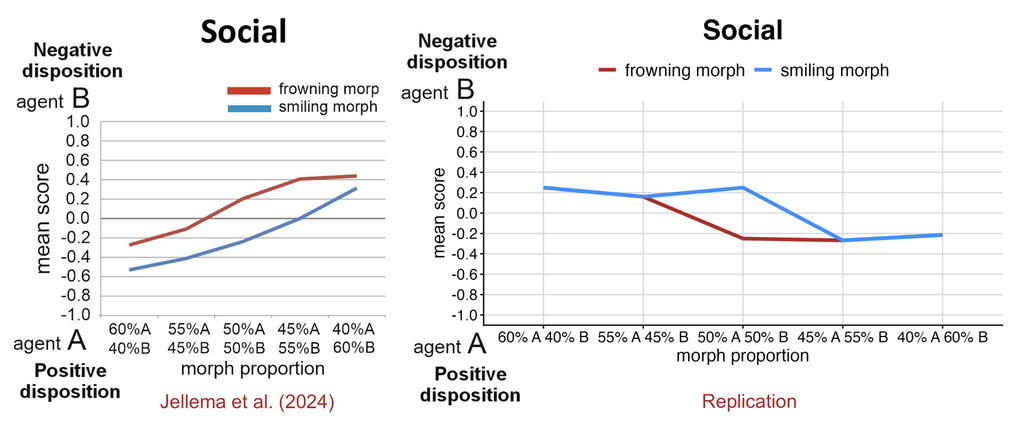

Participants with higher autistic traits were expected to perform worse on the task, but this study found that AQ-10 scores and implicit learning were not significantly correlated (r(26) = -0.037, p = 0.851, 95% CI [-0.405, 0.341], two-tailed) (Figure 2).

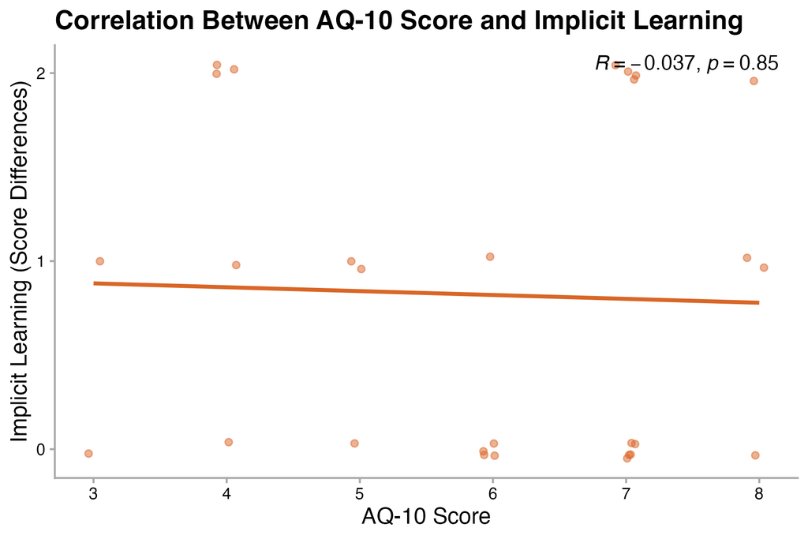

Figure 2. The correlation between AQ-10 scores and the measure of implicit learning.

### Exploratory analyses

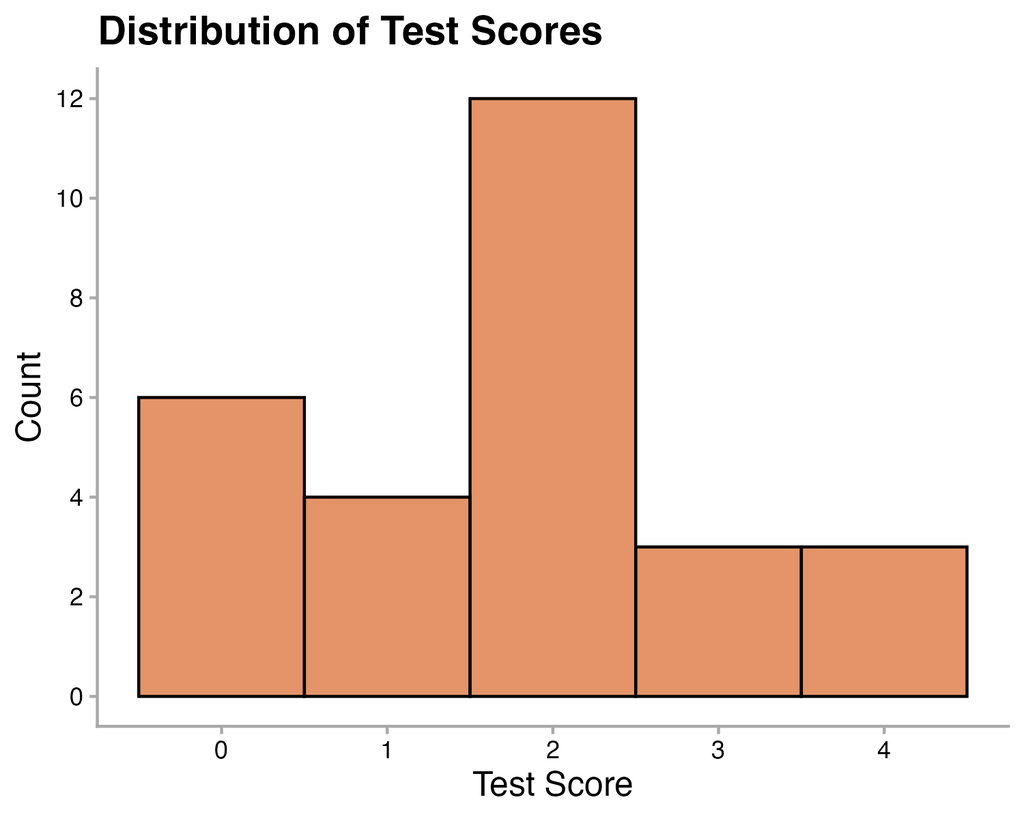

Figure 3. Distribution of total scores on test trials.

The mean score of 5.93 on the AQ-10 for this sample is very close to the threshold for possible autism of six out of 10 points. This shows a relatively high level of autistic traits in the sample. Looking at Figure 4., we can see that the most common score was seven, which is above the threshold. This means the majority of scores were at or above the threshold.

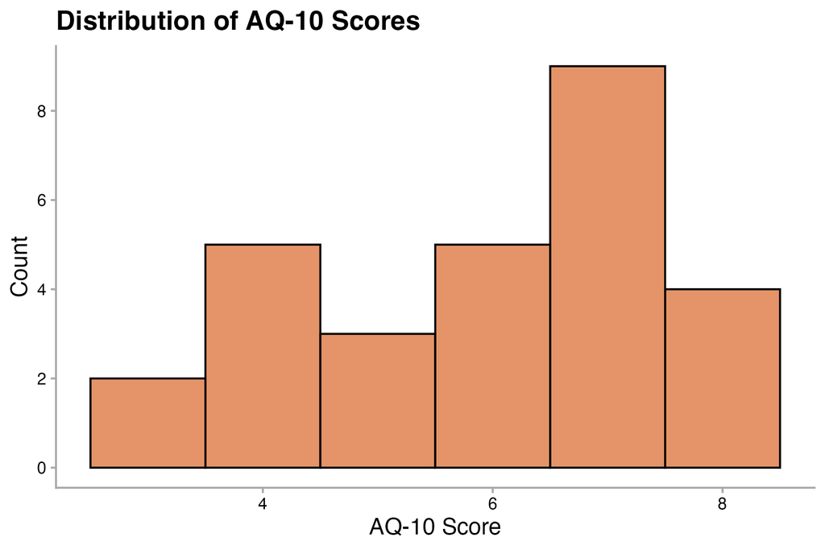

Figure 4. Distribution of AQ-10 scores.

# Discussion

## Summary of Replication Attempt

My analyses found no main effect of disposition or proportion, contrary to Jellema et al. (2024) that found a main effect of both. Neither study found an interaction effect. Additionally, the replication found no correlation between AQ-10 scores and implicit learning. These results mean that Jellema et al. (2024) did not replicate.

## Commentary

One reason that the results did not replicate may have been that it was too challenging to tell the difference between the two identities. Jellema et al. (2024) indicated that the differences between identities A and B were subtle, but they may have made subtle changes to the nose and mouth, which I was not able to do because it would have distorted other aspects of the face in strange ways. I was only able to make changes to the upper half of the face, mostly changing the eyes. While the objective was for participants to identify the face based on the disposition towards them and not based on the facial features, it’s possible that having too little differences between the two faces made it too hard to learn who had which disposition.

The possibility that the two faces were too hard to distinguish is partially supported by 22 out of 28 participants scoring at or below chance with 10 of them scoring below chance. In particular, participants scoring below chance could indicate that they actually learned the inverse pattern, attributing the frowning face to the positive disposition and the smiling face to the negative disposition.

Another potential reason that most participants performed at chance was that there may not have been enough trials for learning to occur. However, I am concerned that more trials would have led more people to detect the contingencies in the experiment as four people detected the contingencies with the current number of trials.